# 12. Unsupervised Learning

GS

28/8/2021

# An Introduction to Statistical Learning (2nd ed.)

### Labs

[An Introduction to Statistcial Learning](https://www.statlearning.com/)

[ISLR tidymodels Labs](https://emilhvitfeldt.github.io/ISLR-tidymodels-labs/linear-regression.html)

## Chapter 12

## Unsupervised Learning

```r
library(tidymodels)
library(ISLR)
library(patchwork)
library(factoextra)

theme_set(theme_bw())
```

```r
usa <- as_tibble(USArrests, rownames = "state")
```

Notice how the mean of each of the variables is quite different. if we were to apply PCA directly to the data set then Murder would have a very small influence.

```r
usa %>%
  select(-state) %>%
  map_dfr(mean)
```

```
# A tibble: 1 x 4
  Murder Assault UrbanPop  Rape
   <dbl>   <dbl>    <dbl> <dbl>
1   7.79    171.     65.5  21.2
```

We will show how to perform PCA in two different ways in this section. First, by using prcomp() directly, using broom to extract the information we need, and secondly by using recipes. prcomp() Takes 1 required argument x which much be a fully numeric data.frame or matrix. Then we pass that to prcomp(). We also set scale = TRUE in prcomp() which will perform the scaling we need.

```r
usa_pca <-
  usa %>%
  select(-state) %>%
  prcomp(scale = T)

usa_pca
```

```
Standard deviations (1, .., p=4):
[1] 1.5748783 0.9948694 0.5971291 0.4164494

Rotation (n x k) = (4 x 4):
                PC1        PC2        PC3         PC4
Murder   -0.5358995  0.4181809 -0.3412327  0.64922780
Assault  -0.5831836  0.1879856 -0.2681484 -0.74340748
UrbanPop -0.2781909 -0.8728062 -0.3780158  0.13387773
Rape     -0.5434321 -0.1673186  0.8177779  0.08902432
```

```r
usa_pca %>%  summary()
```

```
Importance of components:
                          PC1    PC2     PC3     PC4
Standard deviation     1.5749 0.9949 0.59713 0.41645
Proportion of Variance 0.6201 0.2474 0.08914 0.04336
Cumulative Proportion  0.6201 0.8675 0.95664 1.00000
```

```r
tidy(usa_pca)
```

```
# A tibble: 200 x 3
     row    PC  value
   <int> <dbl>  <dbl>
 1     1     1 -0.976
 2     1     2  1.12
 3     1     3 -0.440
 4     1     4  0.155
 5     2     1 -1.93
 6     2     2  1.06
 7     2     3  2.02
 8     2     4 -0.434
 9     3     1 -1.75
10     3     2 -0.738
# ... with 190 more rows
```

```r
#tidy(usa_pca, matrix = "scores")
```

```r
tidy(usa_pca, matrix = "loadings")
```

```
# A tibble: 16 x 3
   column      PC   value
   <chr>    <dbl>   <dbl>
 1 Murder       1 -0.536
 2 Murder       2  0.418
 3 Murder       3 -0.341
 4 Murder       4  0.649
 5 Assault      1 -0.583
 6 Assault      2  0.188
 7 Assault      3 -0.268
 8 Assault      4 -0.743
 9 UrbanPop     1 -0.278
10 UrbanPop     2 -0.873
11 UrbanPop     3 -0.378
12 UrbanPop     4  0.134
13 Rape         1 -0.543
14 Rape         2 -0.167
15 Rape         3  0.818
16 Rape         4  0.0890
```

```r
tidy(usa_pca, matrix = "eigenvalues")
```

```
# A tibble: 4 x 4
     PC std.dev percent cumulative
  <dbl>   <dbl>   <dbl>      <dbl>
1     1   1.57   0.620       0.620
2     2   0.995  0.247       0.868
3     3   0.597  0.0891      0.957
4     4   0.416  0.0434      1
```

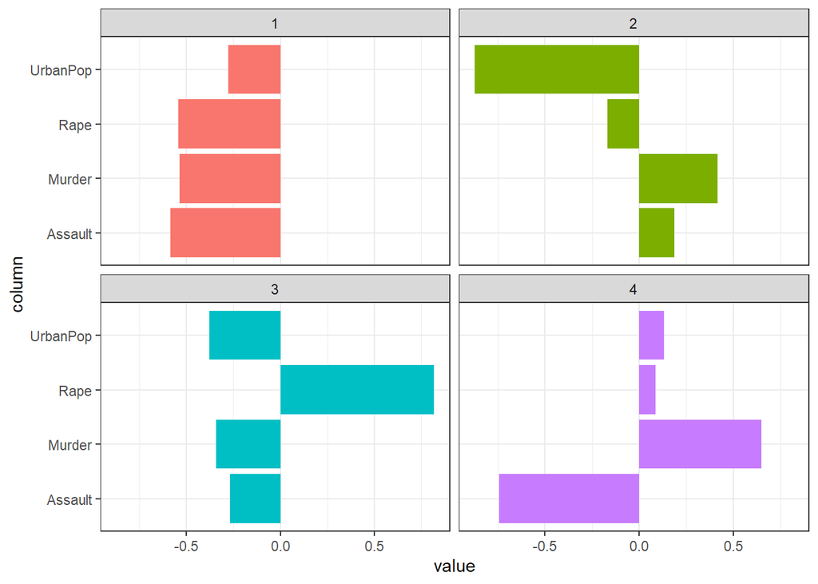

```r
tidy(usa_pca, matrix = "loadings") %>%
  ggplot(aes(value, column, fill = factor(PC))) +
  facet_wrap(~ PC) +
  geom_col() +
  theme(legend.position = "none")
```

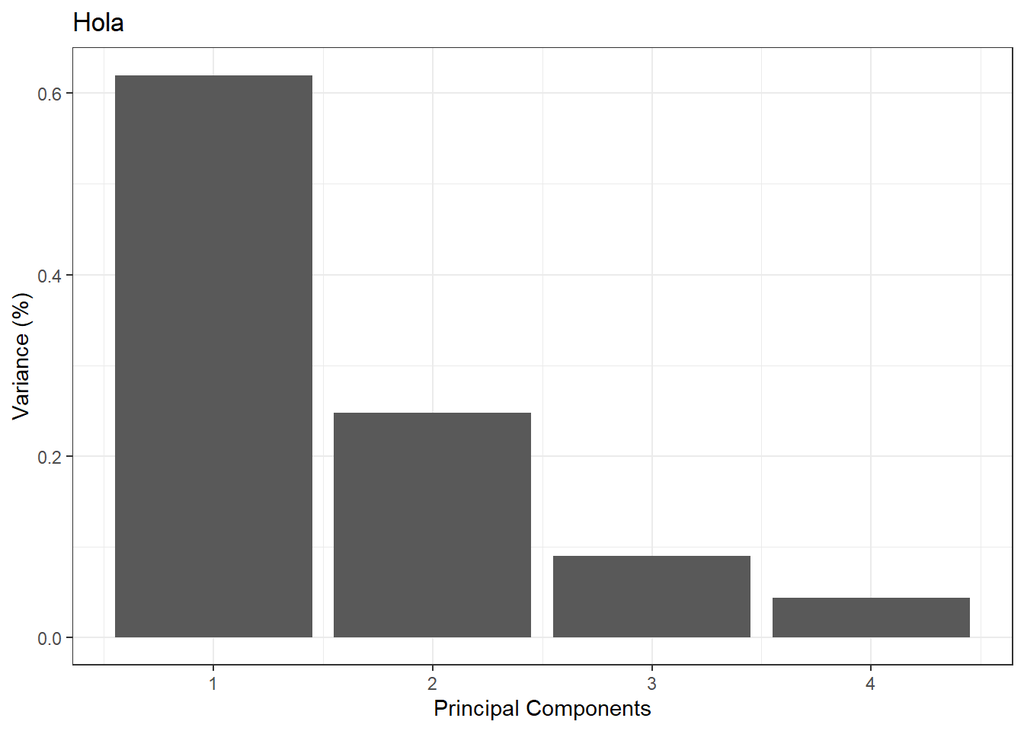

```r
tidy(usa_pca, matrix = "eigenvalues") %>%
  ggplot(aes(PC, percent)) +
  geom_col() +
  labs(x = "Principal Components",
       y = "Variance (%)",
       title = "Hola")
```

```r
augment(usa_pca)
```

```
# A tibble: 50 x 5
   .rownames .fittedPC1 .fittedPC2 .fittedPC3 .fittedPC4
   <chr>          <dbl>      <dbl>      <dbl>      <dbl>
 1 1            -0.976      1.12      -0.440     0.155
 2 2            -1.93       1.06       2.02     -0.434
 3 3            -1.75      -0.738      0.0542   -0.826
 4 4             0.140      1.11       0.113    -0.181
 5 5            -2.50      -1.53       0.593    -0.339
 6 6            -1.50      -0.978      1.08      0.00145
 7 7             1.34      -1.08      -0.637    -0.117
 8 8            -0.0472    -0.322     -0.711    -0.873
 9 9            -2.98       0.0388    -0.571    -0.0953
10 10           -1.62       1.27      -0.339     1.07
# ... with 40 more rows
```

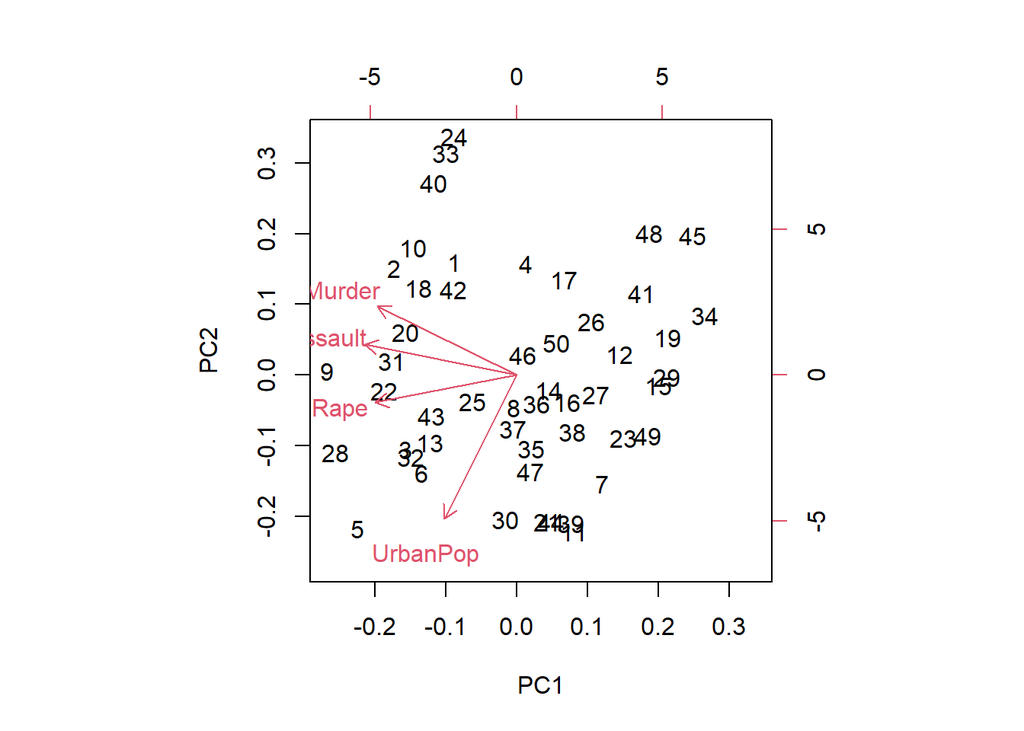

```r
biplot(usa_pca)
```

```r
pca_rec <-
  recipe(~ ., data = usa) %>%
  step_normalize(all_numeric_predictors()) %>%
  step_pca(all_numeric_predictors(), id = "pca") %>%
  prep()

pca_rec %>% juice
```

```
# A tibble: 50 x 5
   state           PC1     PC2     PC3      PC4
   <fct>         <dbl>   <dbl>   <dbl>    <dbl>
 1 Alabama     -0.976   1.12   -0.440   0.155
 2 Alaska      -1.93    1.06    2.02   -0.434
 3 Arizona     -1.75   -0.738   0.0542 -0.826
 4 Arkansas     0.140   1.11    0.113  -0.181
 5 California  -2.50   -1.53    0.593  -0.339
 6 Colorado    -1.50   -0.978   1.08    0.00145
 7 Connecticut  1.34   -1.08   -0.637  -0.117
 8 Delaware    -0.0472 -0.322  -0.711  -0.873
 9 Florida     -2.98    0.0388 -0.571  -0.0953
10 Georgia     -1.62    1.27   -0.339   1.07
# ... with 40 more rows
```

```r
tidy(pca_rec, id = "pca", type = "coef")
```

```
# A tibble: 16 x 4
   terms      value component id
   <chr>      <dbl> <chr>     <chr>
 1 Murder   -0.536  PC1       pca
 2 Assault  -0.583  PC1       pca
 3 UrbanPop -0.278  PC1       pca
 4 Rape     -0.543  PC1       pca
 5 Murder    0.418  PC2       pca
 6 Assault   0.188  PC2       pca
 7 UrbanPop -0.873  PC2       pca
 8 Rape     -0.167  PC2       pca
 9 Murder   -0.341  PC3       pca
10 Assault  -0.268  PC3       pca
11 UrbanPop -0.378  PC3       pca
12 Rape      0.818  PC3       pca
13 Murder    0.649  PC4       pca
14 Assault  -0.743  PC4       pca
15 UrbanPop  0.134  PC4       pca
16 Rape      0.0890 PC4       pca
```

```r
tidy(pca_rec, id = "pca", type = "variance")
```

```
# A tibble: 16 x 4
   terms                         value component id
   <chr>                         <dbl>     <int> <chr>
 1 variance                      2.48          1 pca
 2 variance                      0.990         2 pca
 3 variance                      0.357         3 pca
 4 variance                      0.173         4 pca
 5 cumulative variance           2.48          1 pca
 6 cumulative variance           3.47          2 pca
 7 cumulative variance           3.83          3 pca
 8 cumulative variance           4             4 pca
 9 percent variance             62.0           1 pca
10 percent variance             24.7           2 pca
11 percent variance              8.91          3 pca
12 percent variance              4.34          4 pca
13 cumulative percent variance  62.0           1 pca
14 cumulative percent variance  86.8           2 pca
15 cumulative percent variance  95.7           3 pca
16 cumulative percent variance 100             4 pca
```

```r
pca_rec <-
  recipe(~ ., data = usa) %>%
  step_normalize(all_numeric_predictors()) %>%
  step_pca(all_numeric_predictors(), num_comp = 3) %>%
  prep() %>%
  juice() %>%
  print()
```

```
# A tibble: 50 x 4
   state           PC1     PC2     PC3
   <fct>         <dbl>   <dbl>   <dbl>
 1 Alabama     -0.976   1.12   -0.440
 2 Alaska      -1.93    1.06    2.02
 3 Arizona     -1.75   -0.738   0.0542
 4 Arkansas     0.140   1.11    0.113
 5 California  -2.50   -1.53    0.593
 6 Colorado    -1.50   -0.978   1.08
 7 Connecticut  1.34   -1.08   -0.637
 8 Delaware    -0.0472 -0.322  -0.711
 9 Florida     -2.98    0.0388 -0.571
10 Georgia     -1.62    1.27   -0.339
# ... with 40 more rows
```

```r
pca_rec <-
  recipe(~ ., data = usa) %>%
  step_normalize(all_numeric_predictors()) %>%
  step_pca(all_numeric_predictors(), threshold = .7) %>%
  prep() %>%
  juice() %>%
  print()
```

```
# A tibble: 50 x 3
   state           PC1     PC2
   <fct>         <dbl>   <dbl>
 1 Alabama     -0.976   1.12
 2 Alaska      -1.93    1.06
 3 Arizona     -1.75   -0.738
 4 Arkansas     0.140   1.11
 5 California  -2.50   -1.53
 6 Colorado    -1.50   -0.978
 7 Connecticut  1.34   -1.08
 8 Delaware    -0.0472 -0.322
 9 Florida     -2.98    0.0388
10 Georgia     -1.62    1.27
# ... with 40 more rows
```

## Kmeans Clustering

```r
set.seed(2)

x_df <- tibble(
  V1 = rnorm(n = 50, mean = rep(c(0, 3), each = 25)),
  V2 = rnorm(n = 50, mean = rep(c(0, -4), each = 25))
)
```

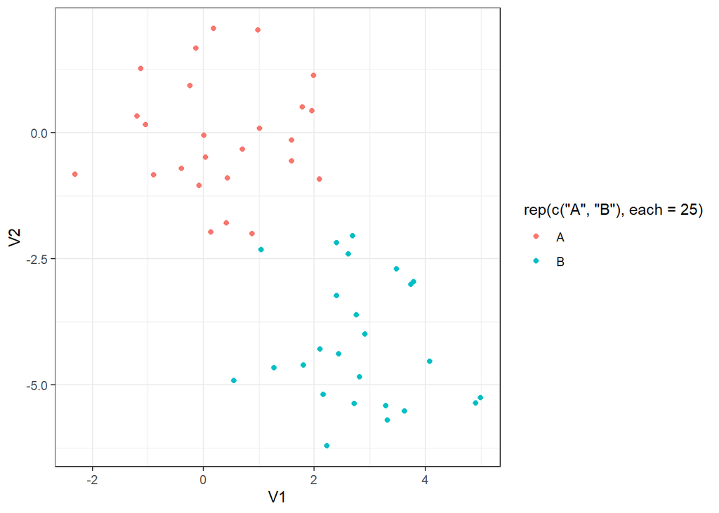

```r
x_df %>%
  ggplot(aes(V1, V2, color = rep(c("A", "B"), each = 25))) +
  geom_point()
```

```r
set.seed(1234)
(res_kmeans <- kmeans(x_df, centers = 3, nstart = 20))
```

```
K-means clustering with 3 clusters of sizes 11, 23, 16

Cluster means:
         V1          V2
1 2.5355362 -2.48605364
2 0.2339095  0.04414551
3 2.8241300 -5.01221675

Clustering vector:
 [1] 2 2 2 2 2 2 2 2 2 2 2 2 2 2 2 2 1 2 2 2 1 2 2 2 2 3 1 1 1 3 1 3 3 3 3 1 3 3
[39] 3 1 1 1 3 3 3 3 1 3 3 3

Within cluster sum of squares by cluster:
[1] 14.56698 54.84869 26.98215
 (between_SS / total_SS =  76.8 %)

Available components:

[1] "cluster"      "centers"      "totss"        "withinss"     "tot.withinss"
[6] "betweenss"    "size"         "iter"         "ifault"
```

```r
tidy(res_kmeans)
```

```
# A tibble: 3 x 5
     V1      V2  size withinss cluster
  <dbl>   <dbl> <int>    <dbl> <fct>
1 2.54  -2.49      11     14.6 1
2 0.234  0.0441    23     54.8 2
3 2.82  -5.01      16     27.0 3
```

```r
augment(res_kmeans, data = x_df)
```

```
# A tibble: 50 x 3
        V1     V2 .cluster
     <dbl>  <dbl> <fct>
 1 -0.897  -0.838 2
 2  0.185   2.07  2
 3  1.59   -0.562 2
 4 -1.13    1.28  2
 5 -0.0803 -1.05  2
 6  0.132  -1.97  2
 7  0.708  -0.323 2
 8 -0.240   0.936 2
 9  1.98    1.14  2
10 -0.139   1.67  2
# ... with 40 more rows
```

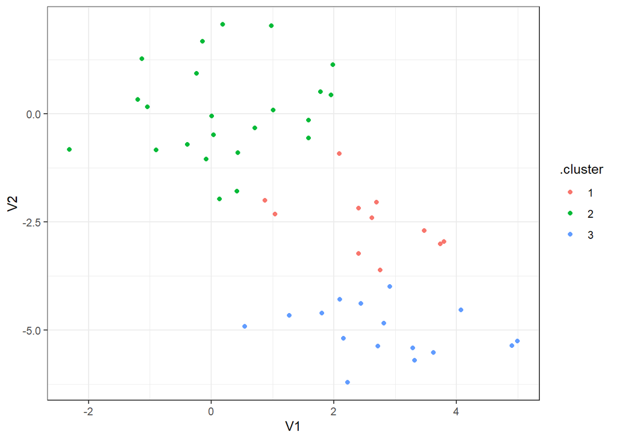

```r
augment(res_kmeans, data = x_df) %>%
  ggplot(aes(V1, V2, color = .cluster)) +
  geom_point()
```

## Hierarchical Clustering

```r
res_hclust_complete <- x_df %>%
  dist() %>%
  hclust(method = "complete")

res_hclust_average <- x_df %>%
  dist() %>%
  hclust(method = "average")

res_hclust_single <- x_df %>%
  dist() %>%
  hclust(method = "single")
```

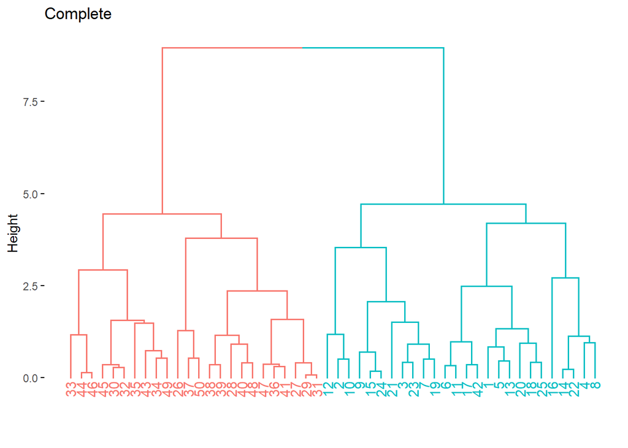

```r
fviz_dend(res_hclust_complete, main = "Complete", k = 2)
```

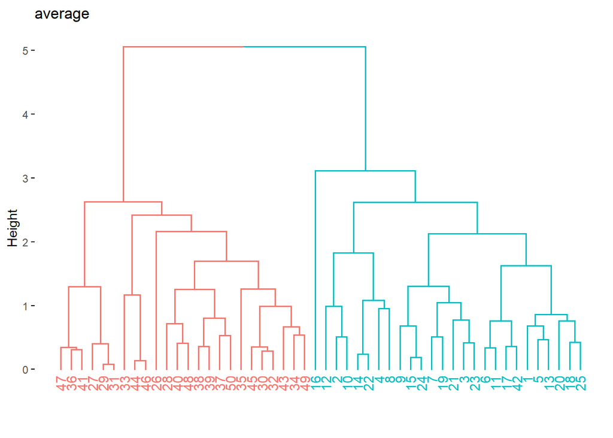

```r
fviz_dend(res_hclust_average, main = "average", k = 2)
```

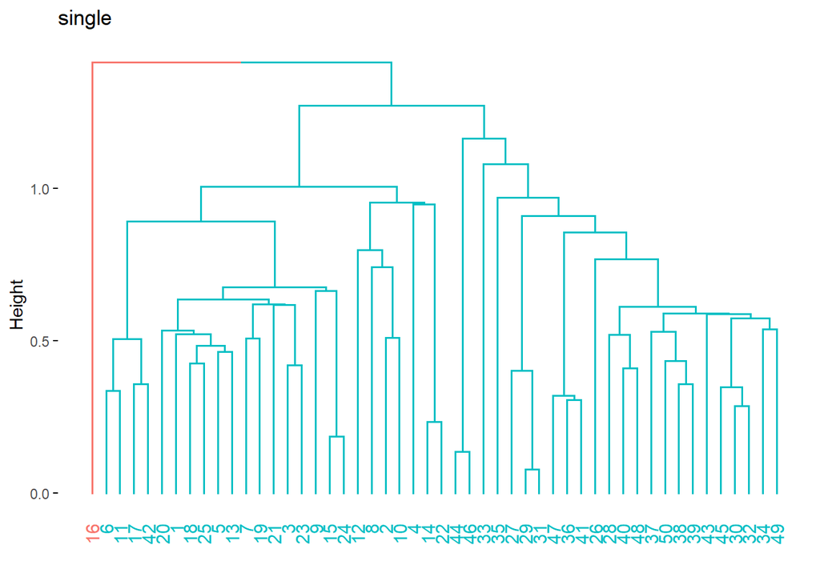

```r
fviz_dend(res_hclust_single, main = "single", k = 2)
```

If we don’t know the importance of the different predictors in data set it could be beneficial to scale the data such that each variable has the same influence. We can perform scaling by using scale() before dist().

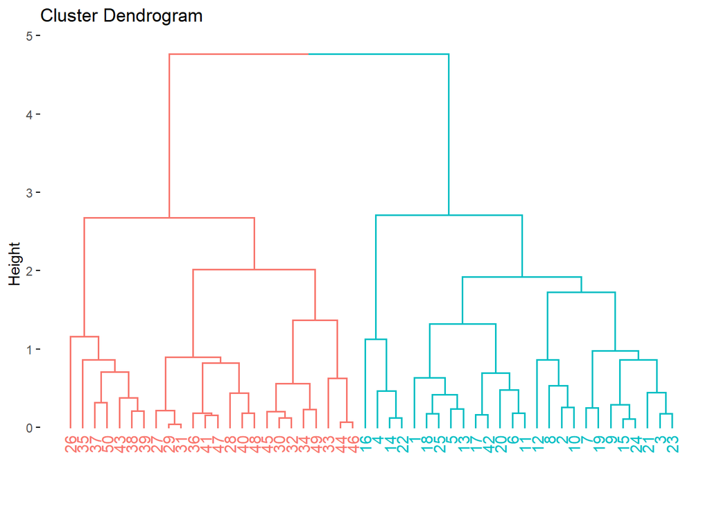

```r
x_df %>%
  scale() %>%
  dist() %>%
  hclust(method = "complete") %>%
  fviz_dend(k = 2)
```

### NCI60 dataset

```r
data(NCI60, package = "ISLR")
nci60 <- NCI60$data %>%
  as_tibble() %>%
  mutate(label = factor(NCI60$labs)) %>%
  relocate(label)
```

```r
nci60_pca <- nci60 %>%
  select(-label) %>%
  prcomp(scale = TRUE)

nci60_pcs <- bind_cols(
  augment(nci60_pca),
  nci60 %>% select(label)
  )

colors <- unname(palette.colors(n = 14, palette = "Polychrome 36"))
```

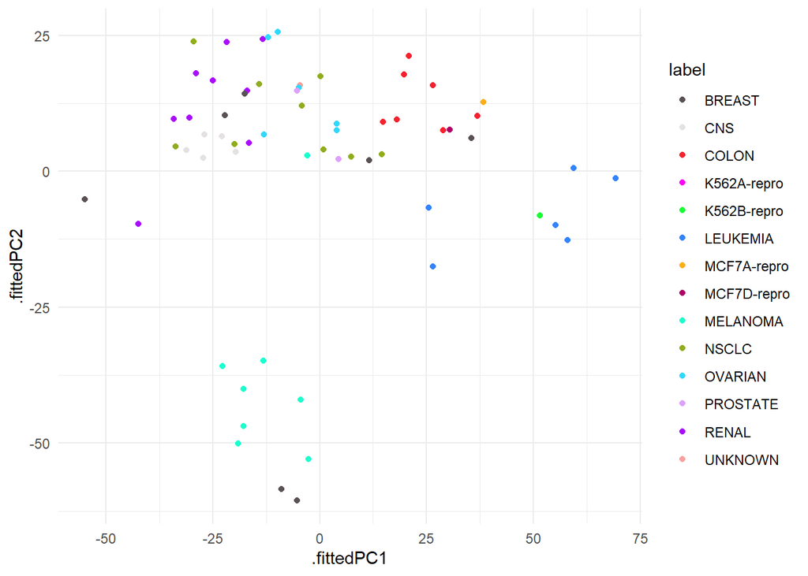

```r
nci60_pcs %>%
  ggplot(aes(.fittedPC1, .fittedPC2, color = label)) +
  geom_point() +
  theme_minimal() +
  scale_color_manual(values = colors)
```

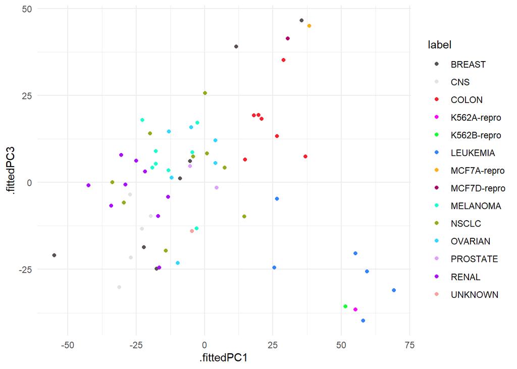

```r
nci60_pcs %>%
  ggplot(aes(.fittedPC1, .fittedPC3, color = label)) +
  geom_point() +
  theme_minimal() +
  scale_color_manual(values = colors)
```

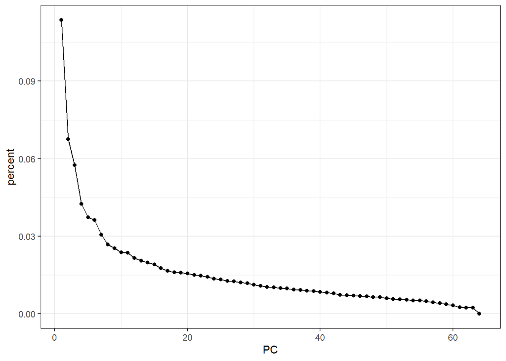

```r
tidy(nci60_pca, matrix = "eigenvalues") %>%
  ggplot(aes(PC, percent)) +
  geom_point() +
  geom_line()
```

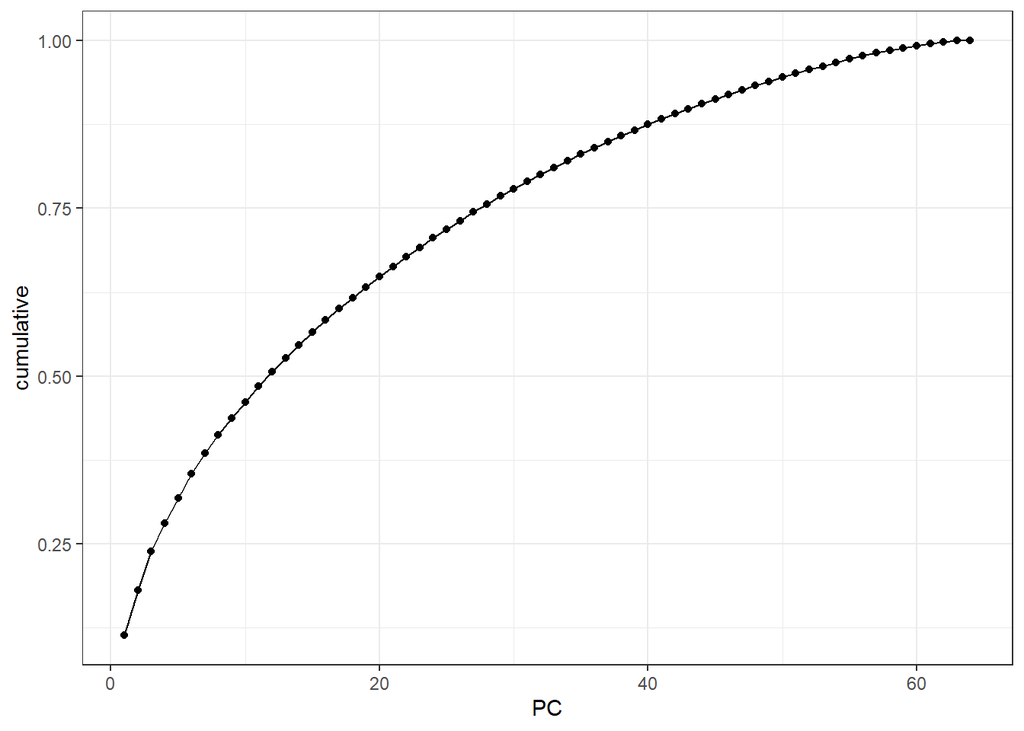

```r
tidy(nci60_pca, matrix = "eigenvalues") %>%
  ggplot(aes(PC, cumulative)) +
  geom_point() +
  geom_line()
```

```r
nci60_scaled <- recipe(~ ., data = nci60) %>%
  step_rm(label) %>%
  step_normalize(all_predictors()) %>%
  prep() %>%
  bake(new_data = NULL)
```

```r
nci60_complete <- nci60_scaled %>%
    dist() %>%
    hclust(method = "complete")

nci60_average <- nci60_scaled %>%
    dist() %>%
    hclust(method = "average")

nci60_single <- nci60_scaled %>%
    dist() %>%
    hclust(method = "single")
```

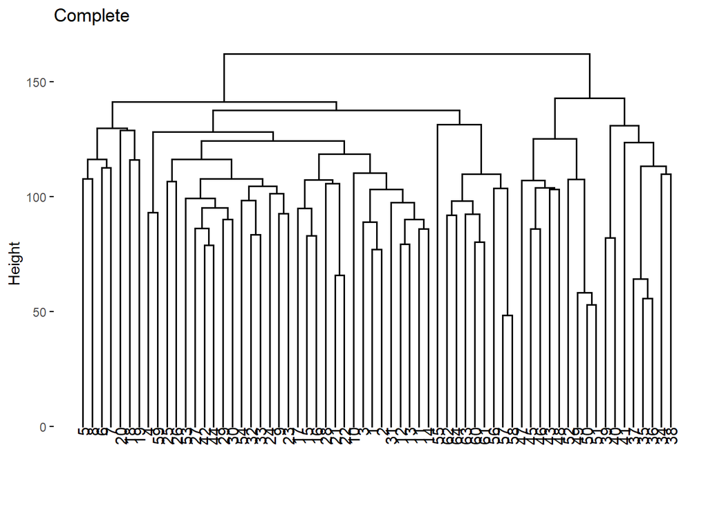

```r
fviz_dend(nci60_complete, main = "Complete")
```

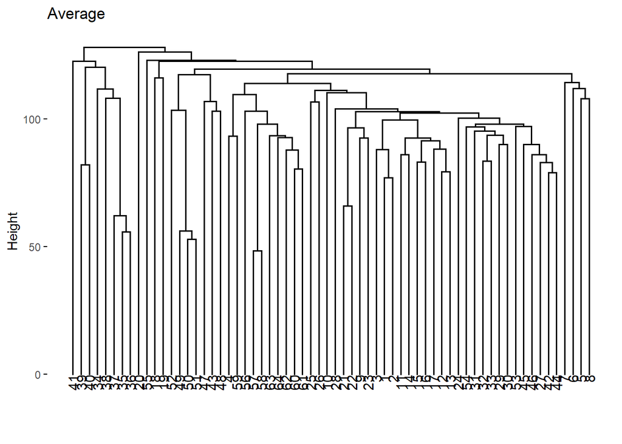

```r
fviz_dend(nci60_average, main = "Average")
```

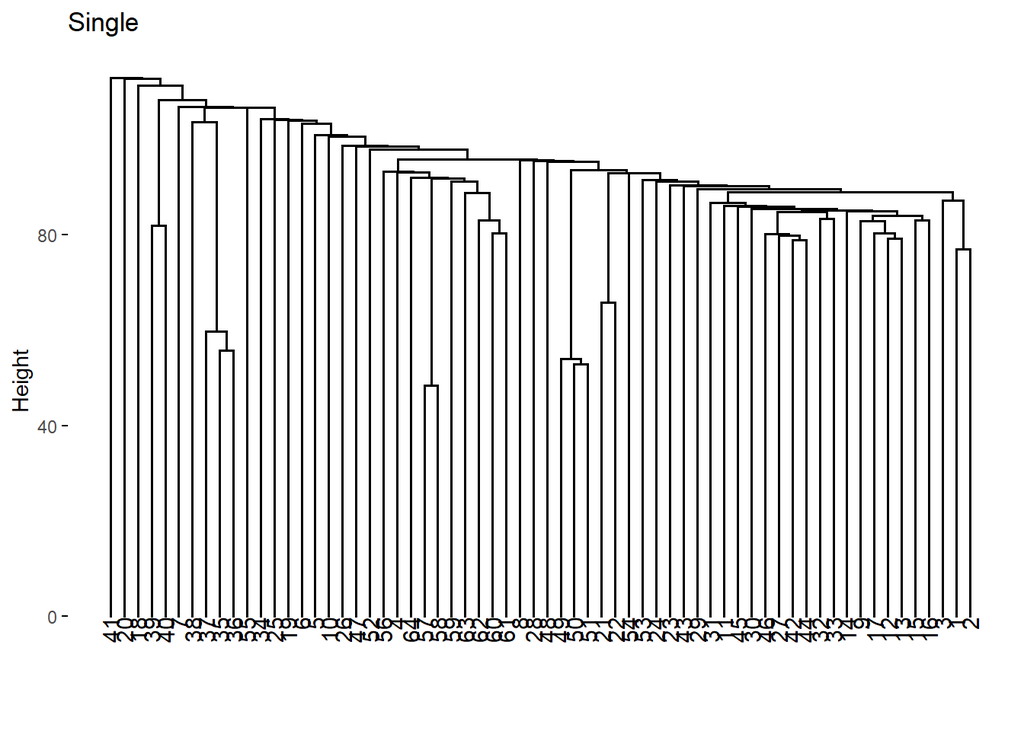

```r
fviz_dend(nci60_single, main = "Single")
```

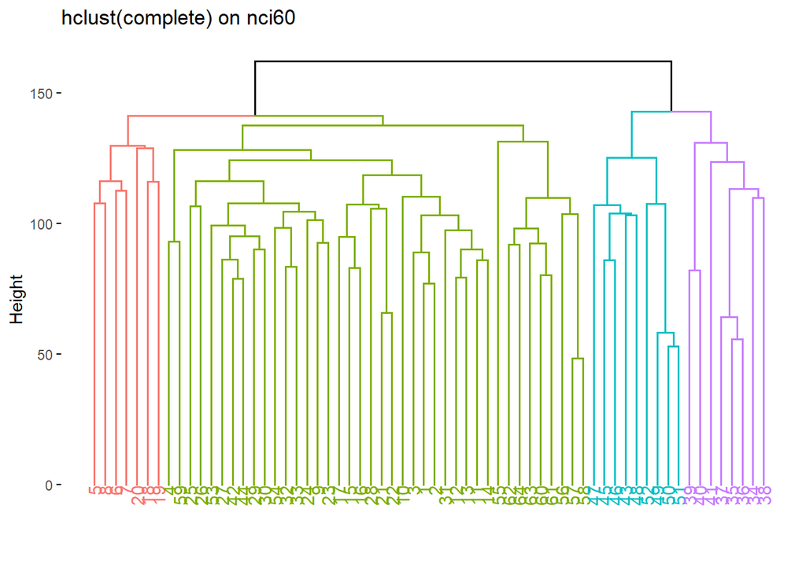

```r
nci60_complete %>%
  fviz_dend(k = 4, main = "hclust(complete) on nci60")
```

Sometimes useful is to perform dimensionality reduction before using the clustering method. Let us use the recipes package to calculate the PCA of nci60 and keep the 5 first components. (we could have started with nci60 too if we added step_rm() and step_normalize()).

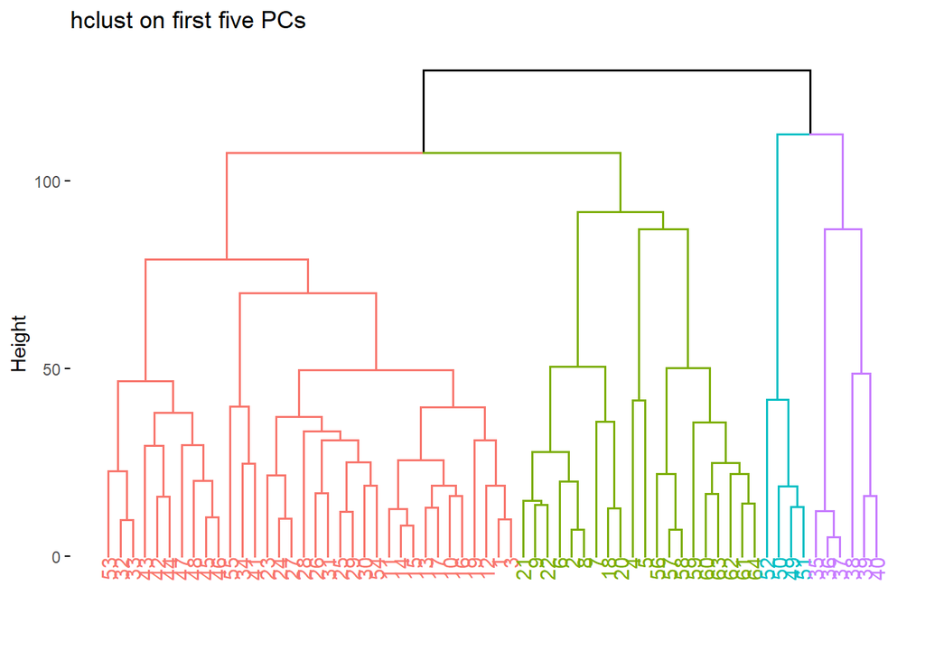

```r
nci60_pca <- recipe(~., nci60_scaled) %>%
  step_pca(all_predictors(), num_comp = 5) %>%
  prep() %>%
  bake(new_data = NULL)

nci60_pca %>%
  dist() %>%
  hclust() %>%
  fviz_dend(k = 4, main = "hclust on first five PCs")
```

[An Introduction to Statistcial Learning](https://www.statlearning.com/)

[ISLR tidymodels Labs](https://emilhvitfeldt.github.io/ISLR-tidymodels-labs/linear-regression.html)

– END